# tRFdb primer (part 2)

Elizabeth Ferrick Kiddie

5/11/2020

### Navigate to the tRNA fragment database:

http://genome.bioch.virginia.edu/trfdb/

### Click on “SEARCH TRFDB”:

[figure not shown]

### Let’s try searching for a specific tRF ID:

##### Try searching for the tRF ID: 3016a (search in all organisms).

Notice that there are tRF IDs for 3016a for both mouse and human, are the sequences the same? Are the fragments derived from the same tRNA type?

**Click for Answer:**

No, the mouse tRF 3016a is derived from tRNA-Serine and the human tRF 3016a is derived from tRNA-Lysine. And when you click on the sequence, you can see that the sequence is not the same. It also looks like the website mislabels the mouse sequence as human in the pop-up window when you click on “Sequence”, and I’ve checked other sequences and this must be a widespread typo.  
Notice that when you click on the “Sequence” link, that the location of the fragment in the sequence is listed as the “Map Position”. This is helpful because later on the fragment abundance is mapped to the position in the tRNA sequence. Use this position number to help you focus on what positions you are most interested in learning about.

### Click on the “Experiments(s)” link for the human chr15.trna2-LysCTT entry to allow a pop-up window to appear

Here is the link to get to this page as well: genome.bioch.virginia.edu/trfdb/**experiments_display**.php?trf_id=**3016a**&organism=**human**  
Notice that the link only contains the tRF ID and the organism type, but not the tRNA name, “chr15.trna2-LysCTT”.

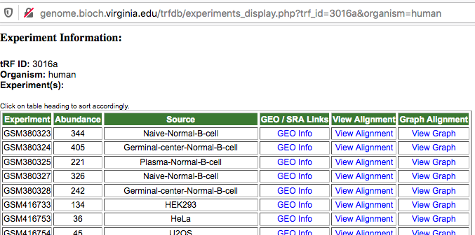

There’s a weird quirk in the website where if you click on the “Experiment(s)” link and access the resulting pages through the pop-up windows, that it doesn’t always link to the correct tRNA gene…that’s actually the original reason I used web scraping to get the data in the first place, because the links were broken, and directed to only one of the isodecoder sequences every time (web scraping turned out to be a much more efficient method of accessing the data, so the solution was better in the end). But, in making this tutorial, I discovered that if you right click on the “Experiment(s)” button and open it in a new tab instead of a pop-up window, this is the link for the page:

genome.bioch.virginia.edu/trfdb/**experiments_display**.php?trf_id=**3016a**&organism=**human**&part1=**chr15-79152904-79152976**&part2=**chr15.trna2-LysCTT**

The link now contains all the specific information regarding the tRNA name and it’s genomic location. This is a much more stable way to look up the data, because you know exactly which tRNA gene you are looking at. So try to remember not to use the automatic pop-up windows on this website and open links in new tabs instead.

##### What does each column give us information about?

**1) Experiment:**

This is the official sample name for the data accessed in the “GEO Info” link in another column.

**2) Abundance:**

[My explanation below probably will make more sense after you go through the tutorial sections: 5) View Alignment and 6) Graph Alignment first]

According to the paper, this column should mark the abundance of the tRF in the dataset, but when I looked at the abundance in the “View Alignment” or “View Graph” links it wasn’t easy to tell where this number was coming from…I finally played around with the numbers and figured out that I think this number is the average abundance of all the nucleotides contained in the fragment sequence (so for the first row, in the “View Graph” page, average the RPM for positions 58 through 76 and you get 344.277).

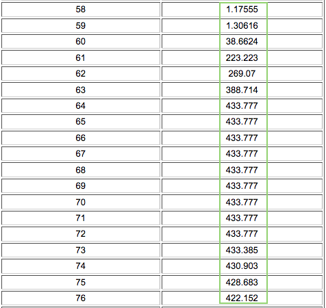

But this is a really flawed quantification, because if you look at the “View Alignment” page from the first row, you’ll see that there are no reads that exactly match tRF 3016a for this experiment (GSM380323)…instead there are only reads that are longer than the tRF sequence (so in reality the abundance should be zero…because we don’t really care about the abundance of individual nucleotides, but the abundance of the intact fragments).

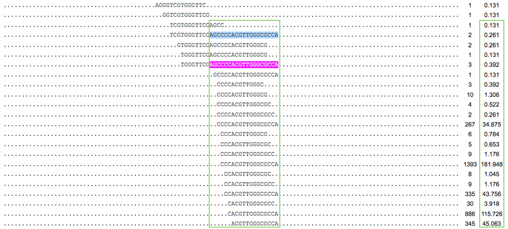

(If you add up the abundances of all the fragments from the “View Alignment” page, it does not equal the Abundance mentioned in the “Experiment” page.)

**3) Source:**

This includes the source of where the RNA came from for the experiment: type of cells, cell line, subcellular location, or the protein the RNA was bound to. For the AGO1-PARCLIP sources, you have to click on the “GEO Info” link to get the type of cell used for the experiment (HEK 293).

**4) GEO / SRA Links:**

This links to the raw data in the Gene Expression Omnibus (GEO) Accession Viewer, and also gives key experimental details on how the sample preparation was done. This raw data can be used by anyone who wants to do further analyses to look for new trends in this public data.

**5) View Alignment:**

Click on the “View Alignment” link on the top row, to go here (it automatically opens in a new tab, no need to right click): genome.bioch.virginia.edu/trfdb/**alignment**.php?exp=**GSM380323**&org=**human**&part1=**chr15-79152904-79152976**&part2=**chr15.trna2-LysCTT**

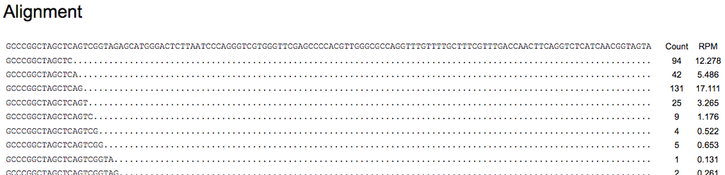

The alignment pages takes us to a visualization of the raw data. The top line is the tRNA gene sequence (also called the reference sequence), but it’s been modified to include the CCA tail, like we’ve seen before:

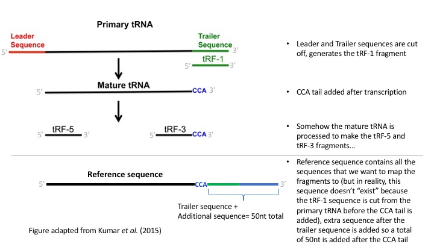

In the “Alignment” page, the lines under the first reference line contain the short RNA sequences (also called reads) which can be matched to the reference tRNA gene sequence, and are shown where on the tRNA gene they align to.  
The Count column gives the number of times that the tRF in that row was found in the experiment we chose. The RPM (reads per million reads) gives a way to normalize the abundance of that RNA, based on how many total RNAs were sequenced. RPM is calculated below:

RPM = $\frac{counts\: of\: RNA\: fragment}{total\: reads\: in\: the\: library/10^6}$

RPM is a simple normalization strategy that is not good when you are looking at fragmented heterogeneous RNA samples, where longer RNAs will dominate over shorter RNAs (RPKM=Reads Per Kilobase Million instead divides the RPM by the length of the RNA you’re measuring, in kilobases, and is a way to not have really long RNAs dominate the measurement of the abundance, though it is still simplistic compared to other normalization strategies). RPM can be an okay measurement of abundance when looking at unfragmented RNAs or looking at RNAs that are all the same length. My assumption, based on all the “GEO Info” links I’ve looked at for the experiments I’ve looked at, is that all the experiments listed on this database are unfragmented and size-selected to only have short RNAs, but it’s always good to check to make sure.

**6) Graph Alignment:**

Click on the “View Graph” link on the top row, to go here (it automatically opens in a new tab, no need to right click): genome.bioch.virginia.edu/trfdb/**graph**.php?exp=**GSM380323**&org=**human**&part1=**chr15-79152904-79152976**&part2=**chr15.trna2-LysCTT**

[figure not shown]

This page includes the numeric data in a table format and that data graphed at the top of the page.

The data are graphed according to the position in the tRNA mature sequence, plus the additional 50nt of downstream sequence they addeded into their reference sequence. The “COUNT” value in the table is really the position in the tRNA reference gene.

**Compare how the reads from the “View Alignment” page compare with the quantification on the “View Graph” page?**

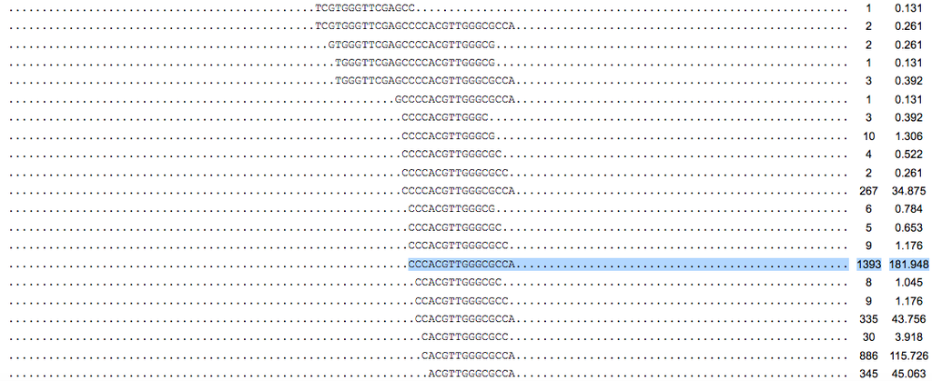

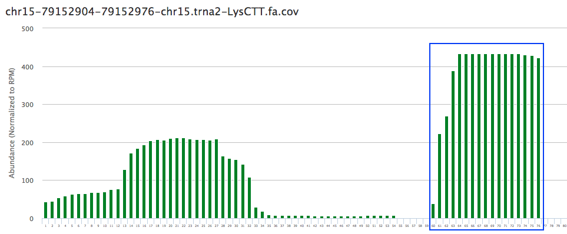

Because there can be a disconnect between the abundance from the “View Graph” page and the “View Alignment” pages, it’s always a good idea to check both pages to see if the abundance on the graph matches actually abundant specific sequences.

**Why is there no data after position 76?**

This is because the mature sequence is 76nt long (including the post-transcriptionally added CCA tail). Remember that tRFdb added 50nt after the mature transcript to monitor any tRNA fragments arising from processing the trailer sequence off (called the tRF-1 fragment with the tRFdb nomeclature). If you look back at the “View Alignment” page, you’ll see that there were no reads associated with tRF-1 sequences, so this is why there are not any values associated with these positions.

**Why are the RPM values different on the “View Alignment” vs “Graph Alignment” pages?**

In the “View Alignment” page, the count information signified how many times that entire grouping of bases was found as a read in the deep sequencing output. In contrast, on this “Graph Alignment” page, the count signifies the position in the tRNA mature sequence and the RPM signifies how often that particular letter was found in the deep sequencing output.  
Screenshot from corresponding “View Alignment” page

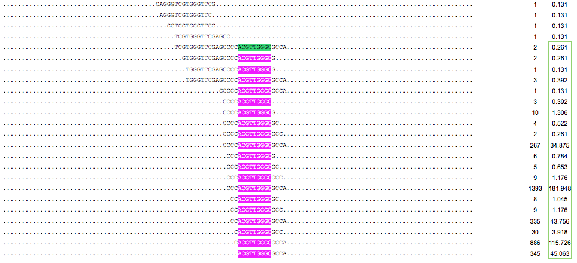

If you click back at the “View Alignment” page, you can search for the sequence “ACGTTGGGC” in the page to see what the RPM of each individual read containing that sequence is. The reads containing that sequence are highlighted above, and includes reads that are longer, but contain the smaller sequence within it. If you add up all the RPM values associated with this sequence, the total is 433.777. The sequence corresponds to positions 64 - 72, and you can confirm the “Graph Alignment” page to see that positions 64 - 72 is quantified as each having 433.777 as it’s RPM value. You can look at adding the RPM values for other positions in the tRNA sequence and confirm that the RPM on the “Graph Alignment” are a tally of the corresponding RPM values found with each read on the “View Alignment” page.

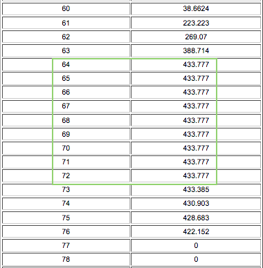

### Let’s look a little closer to the web address associated with the “View Graph” page we were looking at before

##### Is the web address made up of recognizable parts of the tables we viewed up to this point about the tRF and the experiment?

**Click for Answer**

genome.bioch.virginia.edu/trfdb/**graph**.php?exp=**GSM380323**&org=**human**&part1=**chr15-79152904-79152976**&part2=**chr15.trna2-LysCTT**

The link includes:  
1) we’re looking at **graph**  
2) the experiment ID is **GSM380323**  
3) the organism is **human**  
4) the chromosome and location is **chr15-79152904-79152976**  
5) the tRNA name is **chr15.trna2-LysCTT**

All these details match the details of the tRNA links that we clicked to get to this page. Also notice that the same information is in the web address for the “View Alignment” link as well.  
Notice that this page doesn’t include the tRF ID, as it contains the data for all the abundance of each nucleotide position for any tRF for this experiment and this tRNA gene (and includes low expression fragments which they haven’t assigned names to).